# Project_ET

## 1. Importing necessary packages

```python
import numpy as np
import pandas as pd
import matplotlib.pyplot as plt
import seaborn as sns

from scipy import stats
from sklearn.metrics import confusion_matrix
from sklearn.metrics import classification_report

from sklearn.preprocessing import StandardScaler, OneHotEncoder
from sklearn.model_selection import train_test_split

from sklearn.tree import DecisionTreeClassifier
from sklearn.ensemble import BaggingClassifier
from sklearn.ensemble import AdaBoostClassifier
from sklearn.ensemble import GradientBoostingClassifier
from sklearn.ensemble import RandomForestClassifier

import warnings
warnings.filterwarnings('ignore')
```

## 2. Importing Datasets

**Reading the csv files**

```python
df1=pd.read_csv('TelcomCustomer-Churn_1.csv')
df2=pd.read_csv('TelcomCustomer-Churn_2.csv')
```

**Shape of Dataset 1**

```python
df1.shape
```

```
(7043, 10)
```

**Top 5 rows of Dataset 1**

```python
df1.head()
```

|  | customerID | gender | SeniorCitizen | Partner | Dependents | tenure | PhoneService | MultipleLines | InternetService | OnlineSecurity |
| --- | --- | --- | --- | --- | --- | --- | --- | --- | --- | --- |
| 0 | 7590-VHVEG | Female | 0 | Yes | No | 1 | No | No phone service | DSL | No |
| 1 | 5575-GNVDE | Male | 0 | No | No | 34 | Yes | No | DSL | Yes |
| 2 | 3668-QPYBK | Male | 0 | No | No | 2 | Yes | No | DSL | Yes |
| 3 | 7795-CFOCW | Male | 0 | No | No | 45 | No | No phone service | DSL | Yes |
| 4 | 9237-HQITU | Female | 0 | No | No | 2 | Yes | No | Fiber optic | No |

**Shape of Dataset 2**

```python
df2.shape
```

```
(7043, 11)
```

**Top 5 rows of Dataset 2**

```python
df2.head()
```

|  | OnlineBackup | DeviceProtection | TechSupport | StreamingTV | StreamingMovies | Contract | PaperlessBilling | PaymentMethod | MonthlyCharges | TotalCharges | Churn |
| --- | --- | --- | --- | --- | --- | --- | --- | --- | --- | --- | --- |
| 0 | Yes | No | No | No | No | Month-to-month | Yes | Electronic check | 29.85 | 29.85 | No |
| 1 | No | Yes | No | No | No | One year | No | Mailed check | 56.95 | 1889.5 | No |
| 2 | Yes | No | No | No | No | Month-to-month | Yes | Mailed check | 53.85 | 108.15 | Yes |
| 3 | No | Yes | Yes | No | No | One year | No | Bank transfer (automatic) | 42.30 | 1840.75 | No |
| 4 | No | No | No | No | No | Month-to-month | Yes | Electronic check | 70.70 | 151.65 | Yes |

**Combining two Datasets**

```python
df=df1.join(df2,how='inner')
```

**Shape of the final Dataset**

```python
df.shape
```

```
(7043, 21)
```

**Top 5 rows of the Dataset**

```python
df.head()
```

|  | customerID | gender | SeniorCitizen | Partner | Dependents | tenure | PhoneService | MultipleLines | InternetService | OnlineSecurity | ... | DeviceProtection | TechSupport | StreamingTV | StreamingMovies | Contract | PaperlessBilling | PaymentMethod | MonthlyCharges | TotalCharges | Churn |
| --- | --- | --- | --- | --- | --- | --- | --- | --- | --- | --- | --- | --- | --- | --- | --- | --- | --- | --- | --- | --- | --- |
| 0 | 7590-VHVEG | Female | 0 | Yes | No | 1 | No | No phone service | DSL | No | ... | No | No | No | No | Month-to-month | Yes | Electronic check | 29.85 | 29.85 | No |
| 1 | 5575-GNVDE | Male | 0 | No | No | 34 | Yes | No | DSL | Yes | ... | Yes | No | No | No | One year | No | Mailed check | 56.95 | 1889.5 | No |
| 2 | 3668-QPYBK | Male | 0 | No | No | 2 | Yes | No | DSL | Yes | ... | No | No | No | No | Month-to-month | Yes | Mailed check | 53.85 | 108.15 | Yes |
| 3 | 7795-CFOCW | Male | 0 | No | No | 45 | No | No phone service | DSL | Yes | ... | Yes | Yes | No | No | One year | No | Bank transfer (automatic) | 42.30 | 1840.75 | No |
| 4 | 9237-HQITU | Female | 0 | No | No | 2 | Yes | No | Fiber optic | No | ... | No | No | No | No | Month-to-month | Yes | Electronic check | 70.70 | 151.65 | Yes |

5 rows × 21 columns

Let us drop the "customerID" column from the Dataset as it doesn't make sense while building the model

```python
df=df.drop('customerID',axis=1)
```

## 3. Data Cleansing

**Information about Dataset**

```python
df.info()
```

```
<class 'pandas.core.frame.DataFrame'>
RangeIndex: 7043 entries, 0 to 7042
Data columns (total 20 columns):
 #   Column            Non-Null Count  Dtype
---  ------            --------------  -----
 0   gender            7043 non-null   object
 1   SeniorCitizen     7043 non-null   int64
 2   Partner           7043 non-null   object
 3   Dependents        7043 non-null   object
 4   tenure            7043 non-null   int64
 5   PhoneService      7043 non-null   object
 6   MultipleLines     7043 non-null   object
 7   InternetService   7043 non-null   object
 8   OnlineSecurity    7043 non-null   object
 9   OnlineBackup      7043 non-null   object
 10  DeviceProtection  7043 non-null   object
 11  TechSupport       7043 non-null   object
 12  StreamingTV       7043 non-null   object
 13  StreamingMovies   7043 non-null   object
 14  Contract          7043 non-null   object
 15  PaperlessBilling  7043 non-null   object
 16  PaymentMethod     7043 non-null   object
 17  MonthlyCharges    7043 non-null   float64
 18  TotalCharges      7043 non-null   object
 19  Churn             7043 non-null   object
dtypes: float64(1), int64(2), object(17)
memory usage: 1.1+ MB
```

There are no missing values in the dataset

TotalCharges feature should be of type "float" but it is of type "object". This might be because of the occurence of expressions or missing values. Lets check it!

```python
df.TotalCharges.value_counts().head()
```

```
         11
20.2     11
19.75     9
20.05     8
19.65     8
Name: TotalCharges, dtype: int64
```

We can see that there are 11 records in "TotalCharges" with value as empty spaces.

```python
df[df['TotalCharges']==" "]
```

|  | gender | SeniorCitizen | Partner | Dependents | tenure | PhoneService | MultipleLines | InternetService | OnlineSecurity | OnlineBackup | DeviceProtection | TechSupport | StreamingTV | StreamingMovies | Contract | PaperlessBilling | PaymentMethod | MonthlyCharges | TotalCharges | Churn |
| --- | --- | --- | --- | --- | --- | --- | --- | --- | --- | --- | --- | --- | --- | --- | --- | --- | --- | --- | --- | --- |
| 488 | Female | 0 | Yes | Yes | 0 | No | No phone service | DSL | Yes | No | Yes | Yes | Yes | No | Two year | Yes | Bank transfer (automatic) | 52.55 |  | No |
| 753 | Male | 0 | No | Yes | 0 | Yes | No | No | No internet service | No internet service | No internet service | No internet service | No internet service | No internet service | Two year | No | Mailed check | 20.25 |  | No |
| 936 | Female | 0 | Yes | Yes | 0 | Yes | No | DSL | Yes | Yes | Yes | No | Yes | Yes | Two year | No | Mailed check | 80.85 |  | No |
| 1082 | Male | 0 | Yes | Yes | 0 | Yes | Yes | No | No internet service | No internet service | No internet service | No internet service | No internet service | No internet service | Two year | No | Mailed check | 25.75 |  | No |
| 1340 | Female | 0 | Yes | Yes | 0 | No | No phone service | DSL | Yes | Yes | Yes | Yes | Yes | No | Two year | No | Credit card (automatic) | 56.05 |  | No |
| 3331 | Male | 0 | Yes | Yes | 0 | Yes | No | No | No internet service | No internet service | No internet service | No internet service | No internet service | No internet service | Two year | No | Mailed check | 19.85 |  | No |
| 3826 | Male | 0 | Yes | Yes | 0 | Yes | Yes | No | No internet service | No internet service | No internet service | No internet service | No internet service | No internet service | Two year | No | Mailed check | 25.35 |  | No |
| 4380 | Female | 0 | Yes | Yes | 0 | Yes | No | No | No internet service | No internet service | No internet service | No internet service | No internet service | No internet service | Two year | No | Mailed check | 20.00 |  | No |
| 5218 | Male | 0 | Yes | Yes | 0 | Yes | No | No | No internet service | No internet service | No internet service | No internet service | No internet service | No internet service | One year | Yes | Mailed check | 19.70 |  | No |
| 6670 | Female | 0 | Yes | Yes | 0 | Yes | Yes | DSL | No | Yes | Yes | Yes | Yes | No | Two year | No | Mailed check | 73.35 |  | No |
| 6754 | Male | 0 | No | Yes | 0 | Yes | Yes | DSL | Yes | Yes | No | Yes | No | No | Two year | Yes | Bank transfer (automatic) | 61.90 |  | No |

Let us replace these empty space values with zero

```python
df['TotalCharges']=df['TotalCharges'].replace(" ",0)
```

**Changing the type of "SeniorCitizen" as Categorical/Object and "TotalCharges" as float**

```python
df['SeniorCitizen']=df['SeniorCitizen'].astype("object")
df['TotalCharges']=df['TotalCharges'].astype("float64")
```

**Checking for duplicate entries in the Dataset**

```python
Duplicate = df[df.duplicated(keep='first')]

print("Duplicate Rows :")

Duplicate.shape
```

```
Duplicate Rows :
```

```
(22, 20)
```

There are 22 duplicate records in the Dataset and let us drop them from the dataset

```python
df.drop_duplicates(keep='first',inplace=True)
```

**Shape of the dataset after removing the duplicate entries**

```python
df.shape
```

```
(7021, 20)
```

Duplicate records are removed

**Information about Dataset after data cleansing**

```python
df.info()
```

```
<class 'pandas.core.frame.DataFrame'>
Int64Index: 7021 entries, 0 to 7042
Data columns (total 20 columns):
 #   Column            Non-Null Count  Dtype
---  ------            --------------  -----
 0   gender            7021 non-null   object
 1   SeniorCitizen     7021 non-null   object
 2   Partner           7021 non-null   object
 3   Dependents        7021 non-null   object
 4   tenure            7021 non-null   int64
 5   PhoneService      7021 non-null   object
 6   MultipleLines     7021 non-null   object
 7   InternetService   7021 non-null   object
 8   OnlineSecurity    7021 non-null   object
 9   OnlineBackup      7021 non-null   object
 10  DeviceProtection  7021 non-null   object
 11  TechSupport       7021 non-null   object
 12  StreamingTV       7021 non-null   object
 13  StreamingMovies   7021 non-null   object
 14  Contract          7021 non-null   object
 15  PaperlessBilling  7021 non-null   object
 16  PaymentMethod     7021 non-null   object
 17  MonthlyCharges    7021 non-null   float64
 18  TotalCharges      7021 non-null   float64
 19  Churn             7021 non-null   object
dtypes: float64(2), int64(1), object(17)
memory usage: 1.1+ MB
```

## 4. Data analysis & Visualization

### 5 Point summary

```python
df.describe()
```

|  | tenure | MonthlyCharges | TotalCharges |
| --- | --- | --- | --- |
| count | 7021.000000 | 7021.000000 | 7021.000000 |
| mean | 32.469449 | 64.851894 | 2286.765026 |
| std | 24.534965 | 30.069001 | 2266.855057 |
| min | 0.000000 | 18.250000 | 0.000000 |
| 25% | 9.000000 | 35.750000 | 403.350000 |
| 50% | 29.000000 | 70.400000 | 1400.550000 |
| 75% | 55.000000 | 89.900000 | 3801.700000 |
| max | 72.000000 | 118.750000 | 8684.800000 |

**Insights from the above analysis**

```
mean of "tenure" is slightly greater than its median - possiblity of right skewness

mean of "MonthlyCharges" is lesser than its median - possiblity of left skewness

mean of "TotalCharges" is very much greater than its median - very high possiblity of right skewness
```

### Univariate analysis

*Univariate analysis on continuous variable*

```
 TENURE
```

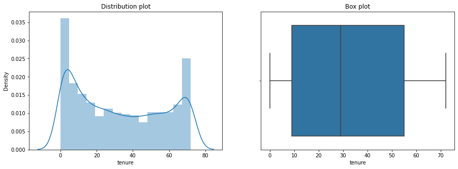

```
Total number of outliers in tenure: 0
Percentage of outliers in tenure: 0.0 %


 MONTHLYCHARGES
```

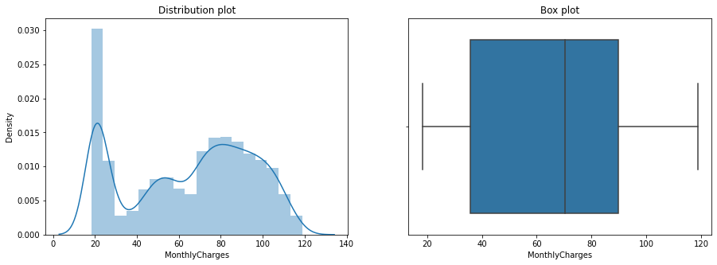

```
Total number of outliers in MonthlyCharges: 0
Percentage of outliers in MonthlyCharges: 0.0 %


 TOTALCHARGES
```

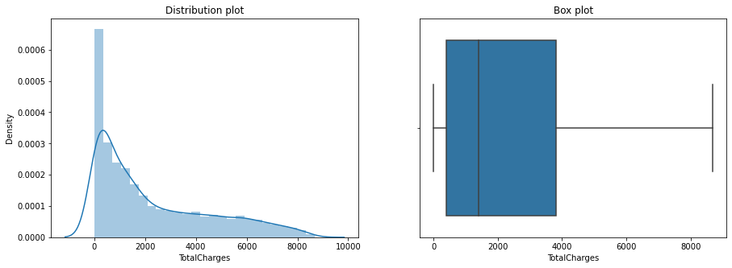

```
Total number of outliers in TotalCharges: 0
Percentage of outliers in TotalCharges: 0.0 %
```

```python
num_cols=[i for i in df.columns if df[i].dtypes!='O']

for i in num_cols:
    print('{} \n\n {}'.format('\033[1m',i.upper()))
    f, axes = plt.subplots(1, 2, figsize=(15,5))
    sns.boxplot(x = i, data=df,  orient='h' , ax=axes[1])
    sns.distplot(df[i],  ax=axes[0])
    axes[0].set_title('Distribution plot')
    axes[1].set_title('Box plot')
    plt.show()


    q25,q75=np.percentile(df[i],25),np.percentile(df[i],75)
    IQR=q75-q25
    Threshold=IQR*1.5
    lower,upper=q25-Threshold,q75+Threshold
    Outliers=[i for i in df[i] if i<lower or i>upper]
    print('Total number of outliers in {}: {}'.format(i,len(Outliers)))
    percent=round((len(Outliers)/len(df[i]))*100,2)
    print('Percentage of outliers in {}: {} %'.format(i,percent))
```

**Insights from the above analysis**

```
There are no outliers in the dataset but the dataset is not normally distributed
```

*Univariate analysis on categorical variable*

```python
obj_cols=[i for i in df.columns if df[i].dtypes=='O']
```

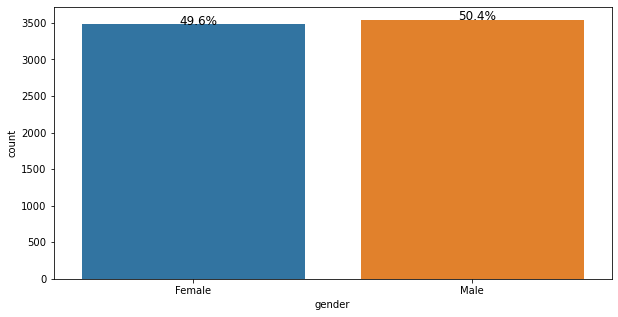

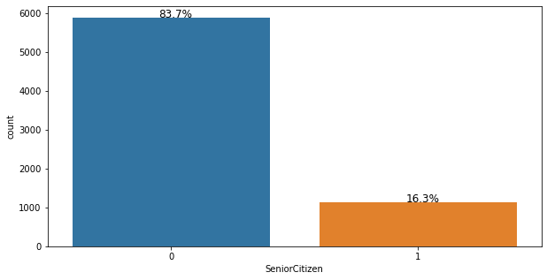

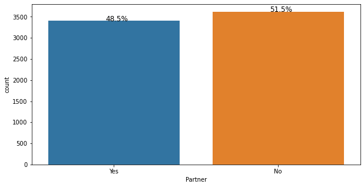

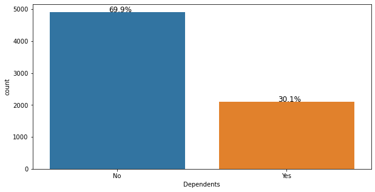

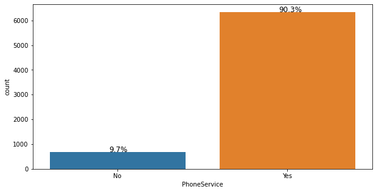

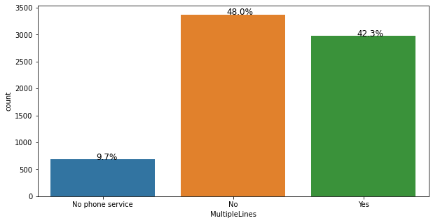

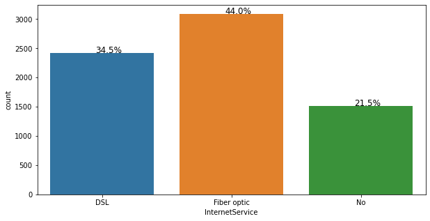

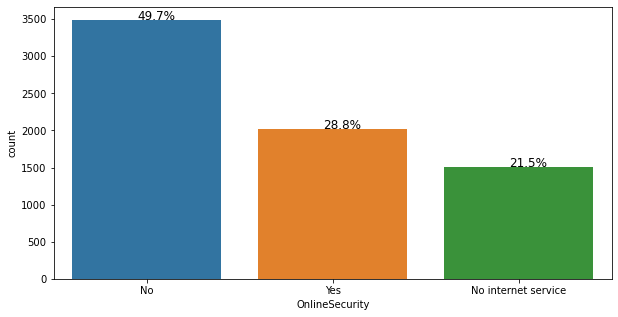

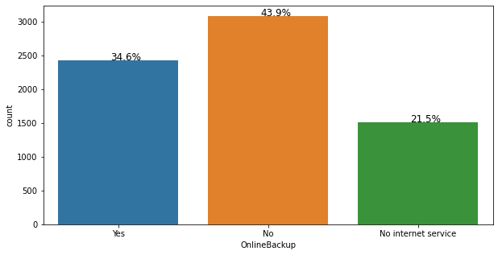

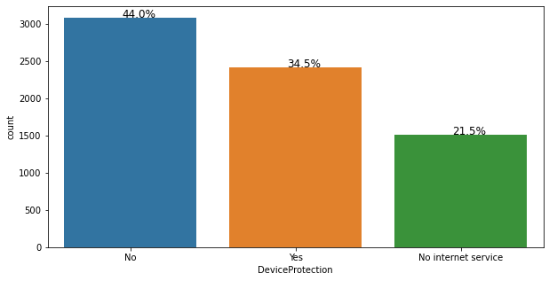

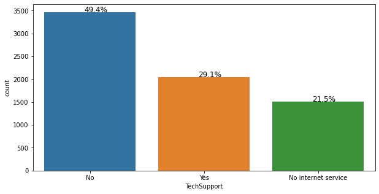

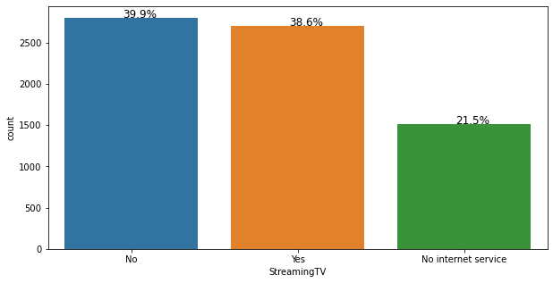

[5 more figures not shown]

```python
for i in obj_cols:
    plt.figure(figsize=(10,5))
    plot=sns.countplot(df[i])

    total = len(df[i])
    for p in plot.patches:
        percentage = '{:.1f}%'.format(100 * p.get_height()/total)
        x = p.get_x() + p.get_width() / 2 - 0.05
        y = p.get_y() + p.get_height()
        plot.annotate(percentage, (x, y), size = 12)

    plt.show()
```

**Insights from the above analysis**

-*gender* - Male and Female count is almost equally distributed

-*SeniorCitizen* - Senior citizens are less when compared to non-senior citizens

-*Partner* - Half of the customers do not have partners

-*Dependents* - Almost 70% of the customers do not have dependents

-*PhoneService* - 90% of the customers have signed for PhoneService

-*MultipleLines* - Half of the customers did not opt for MultipleLines

-*InternetService* - 21.5% of the customers did not sign for internet service, while remaining 78.5% have signed

-*OnlineSecurity* - 50% of the customers did not sign for OnlineSecurity, 28.8% have signed for OnlineSecurity while the remaining 21.5% did not sign for InternetServices

-*OnlineBackup* - 43.9% of the customers did not sign for OnlineBackup, 34.6% have signed for OnlineBackup while the remaining 21.5% did not sign for InternetServices

-*DeviceProtection* - 44% of the customers did not sign for DeviceProtection, 34.5% have signed for OnlineSecurity while the remaining 21.5% did not sign for InternetServices

-*TechSupport* - 49.4% of the customers did not sign for TechSupport, 29.1% have signed for TechSupport while the remaining 21.5% did not sign for InternetServices

-*StreamingTV* - Almost equal amount of customers have signed for StreamingTV services,while 21.5% did not sign for InternetServices

-*StreamingMovies* - Almost equal amount of customers have signed for StreamingMovie services,while 21.5% did not sign for InternetServices

**OnlineSecurity,OnlineBackup,DeviceProtection,TechSupport,StreamingTV,StreamingMovies seems to be correlated with InternetService, because it is obvious that customers who didn't sign for InternetService will not get the above mentioned services**

-*Contract* - 54.9% of customers have Month-to-Month contract,21% have One year contract and 24.1% have Two year contract

-*PaperlessBilling* - 60% of customers have Paperless billing

-*PaymentMethod* - 33.6% of customers choose Electronic check as their payment method, while remaining choose either Mailed check or Bank transfer(automatic) or Credit card(automatic)

-*Churn* - 26.4% of customers left the Telecom while 73.6% of customers did not left(Target variable is imbalanced)

### Bivariate Analysis

*Numerical variable vs Target variable*

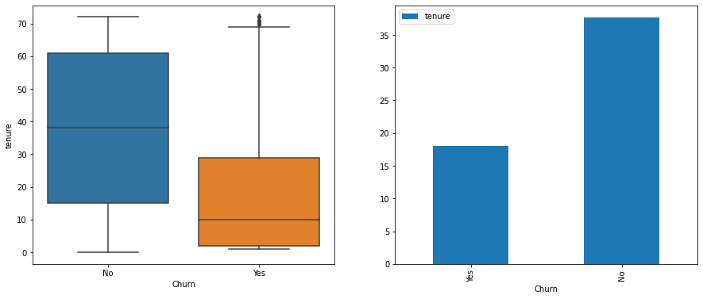

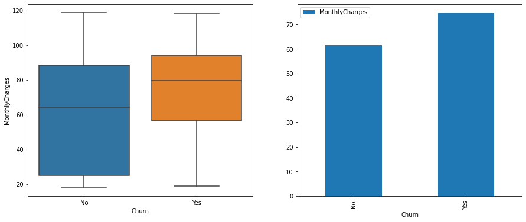

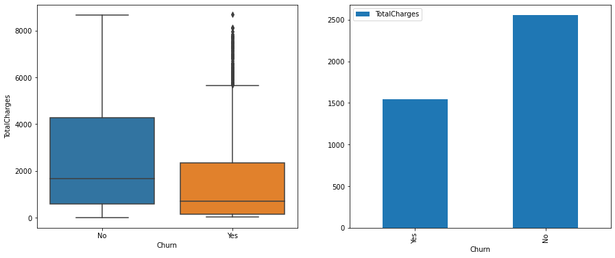

```python
for i in num_cols:
    f,axes=plt.subplots(1,2,figsize=(15,6))
    sns.boxplot(x='Churn', y=i, data= df, ax=axes[0])
    df.groupby(by=['Churn'])[i].mean().reset_index().sort_values(i,ascending=True).plot(x='Churn',y=i,kind='bar',ax=axes[1])
```

**Insights from the above analysis**

-Customers who have less tenure period have churned.

-Some customers might have churned because of high average Monthly charges.

-Most of the customers did not churn eventhough the TotalCharge is high, but some of them have churned because of high Totalcharge

*Categorical variable vs Target variable*

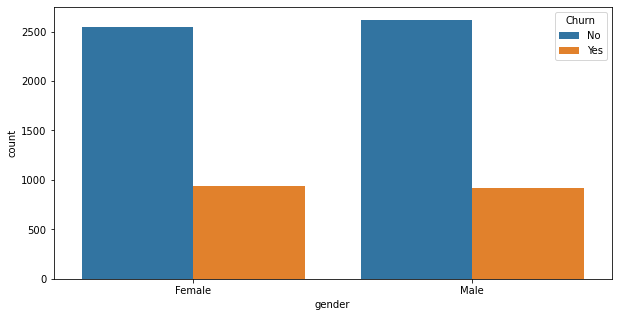

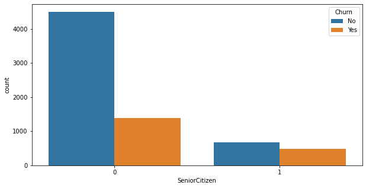

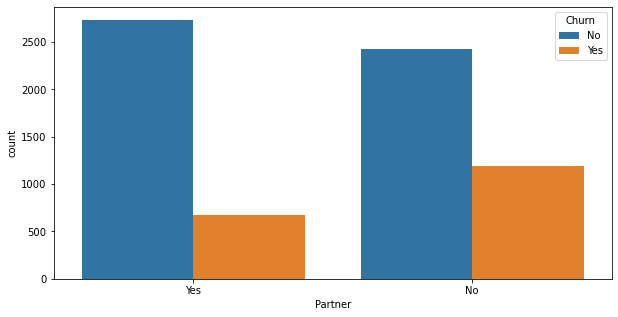

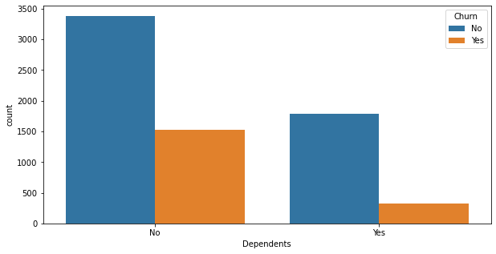

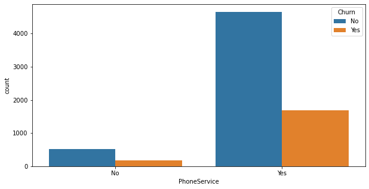

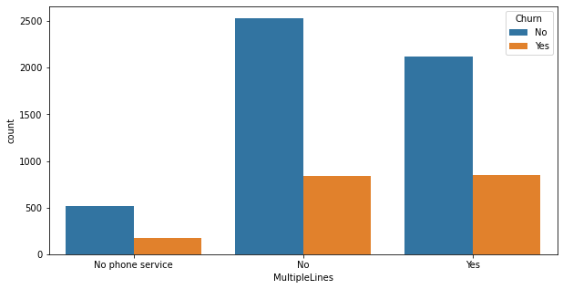

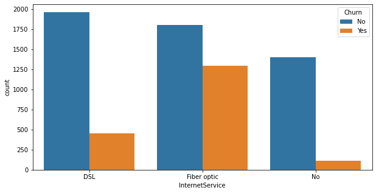

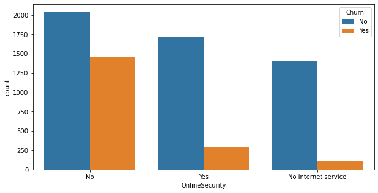

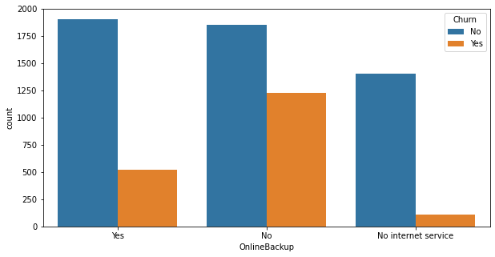

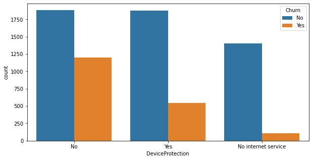

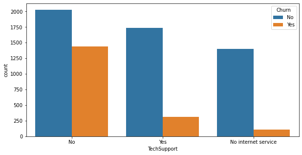

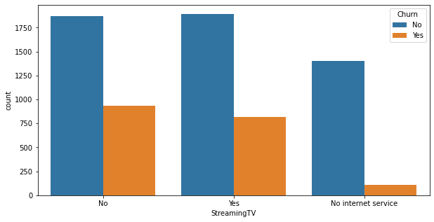

[4 more figures not shown]

```python
for i in obj_cols:
    if i!='Churn':
        plt.figure(figsize=(10,5))
        sns.countplot(df[i],hue=df['Churn'])
        plt.show()
```

**Insights from the above analysis**

-We cannot draw any conclusion based on gender,because both female and male have churned equally

-Customers with no partners,no dependents have churned more.

-Customers who have signed for Fiber optic internet service have churned more when compared to the Customers who have signed for DSL and who have not signed for any kind of internet services

-Customers who have not signed for internet services like OnlineSecurity, OnlineBackup, DeviceProtection, TechSupport have churned more. Whereas we cannot find any strong insights from other services like StreamingTV,StreamingMovies because Customers have churned no matter what whether they have signed for them or not.

-Customers with Month-to-month contract churned the most. This tells us that the Customers with longer contract period do not churn.

-Customers who have their payment method as Electronic check has churned more

*Multivariate analysis*

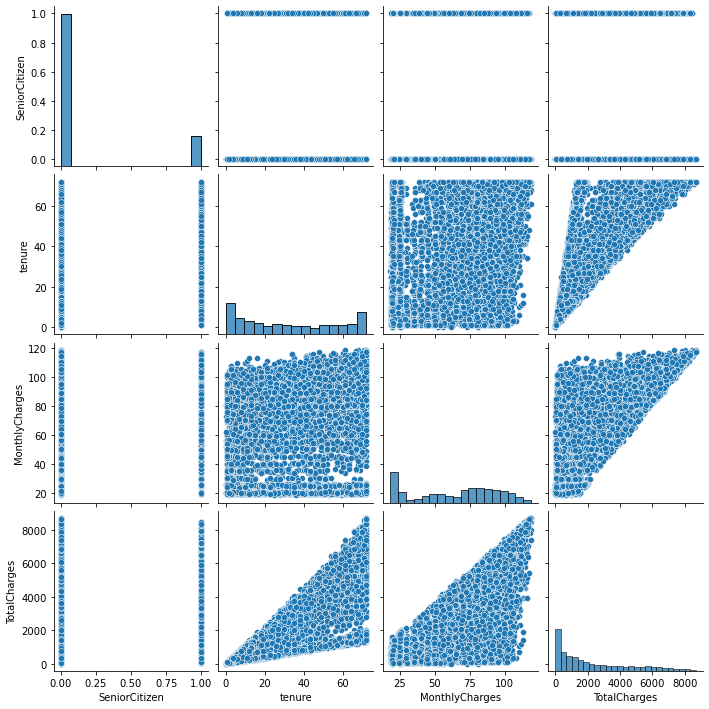

```python
sns.pairplot(df);
```

**Insights from the above analysis**

Tenure seems like it doesn't form any pattern with MonthlyCharges,whereas all other features form a kind of linear pattern

#### Correlation heatmap

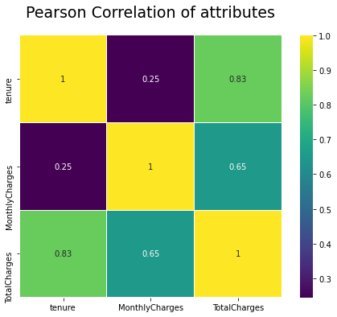

```python
colormap = plt.cm.viridis # Color range to be used in heatmap
plt.figure(figsize=(8,6))
plt.title('Pearson Correlation of attributes', y=1.05, size=19)
sns.heatmap(df.corr(),linewidths=0.1,vmax=1.0,
            square=True, cmap=colormap, linecolor='white', annot=True)
```

### Feature selection

Let us use hypothesis testing for feature selection process

*Statistical testing of continuous feature with target feature*

```python
for i in num_cols:
    x = np.array(df[df.Churn=='No'][i])
    y = np.array(df[df.Churn=='Yes'][i])

    t, p_value  = stats.ttest_ind(x,y, axis = 0,equal_var=False)

    print('{} P_Value:{}'.format('\033[1m',p_value))
    if p_value < 0.05:  # Setting our significance level at 5%
        print('{} Rejecting Null Hypothesis. \n There is significant difference in {} Feature for different category of target variable'.format('\033[1m',i))
    else:
        print('{} Fail to Reject Null Hypothesis.\n There is no significant difference in {} Feature for different category of target variable'.format('\033[1m',i))
    print('\n')
```

```
 P_Value:1.4676429262286135e-230
 Rejecting Null Hypothesis.
 There is significant difference in tenure Feature for different category of target variable


 P_Value:1.3728045525067781e-73
 Rejecting Null Hypothesis.
 There is significant difference in MonthlyCharges Feature for different category of target variable


 P_Value:7.600819496523335e-74
 Rejecting Null Hypothesis.
 There is significant difference in TotalCharges Feature for different category of target variable
```

The features "tenure","MonthlyCharges","TotalCharges" are required for our model building

*Statistical testing of categorical feature with target feature*

```python
for i in obj_cols:
    crosstab=pd.crosstab(df["Churn"],df[i])

    chi,p_value,dof,expeced = stats.chi2_contingency(crosstab)

    if p_value < 0.05:  # Setting our significance level at 5%
        print('{} Rejecting Null Hypothesis. \n There is significant difference in {} Feature for different category of target variable'.format('\033[1m',i))
    else:
        print('{} Fail to Reject Null Hypothesis.\n There is no significant difference in {} Feature for different category of target variable'.format('\033[1m',i))
    print(crosstab)
    print('\n')
```

```
 Fail to Reject Null Hypothesis.
 There is no significant difference in gender Feature for different category of target variable
gender  Female  Male
Churn
No        2546  2618
Yes        934   923


 Rejecting Null Hypothesis.
 There is significant difference in SeniorCitizen Feature for different category of target variable
SeniorCitizen     0    1
Churn
No             4498  666
Yes            1382  475


 Rejecting Null Hypothesis.
 There is significant difference in Partner Feature for different category of target variable
Partner    No   Yes
Churn
No       2431  2733
Yes      1188   669


 Rejecting Null Hypothesis.
 There is significant difference in Dependents Feature for different category of target variable
Dependents    No   Yes
Churn
No          3380  1784
Yes         1531   326


 Fail to Reject Null Hypothesis.
 There is no significant difference in PhoneService Feature for different category of target variable
PhoneService   No   Yes
Churn
No            512  4652
Yes           170  1687


```

[output cut: 84 more lines]

```
No                                  1286                     1290
Yes                                  258                      232

PaymentMethod  Electronic check  Mailed check
Churn
No                         1294          1294
Yes                        1065           302


 Rejecting Null Hypothesis.
 There is significant difference in Churn Feature for different category of target variable
Churn    No   Yes
Churn
No     5164     0
Yes       0  1857
```

We can see gender,PhoneService does not have effect on target variable. So dropping these columns before building model

```python
df.drop(['gender','PhoneService'],axis=1,inplace=True)
```

## 5. Data preprocessing

### Encoding target variable

```python
df['Churn']=df['Churn'].replace({"Yes": 1,"No": 0})
```

### Outlier analysis

During Univariate analysis we have seen that there are no outliers in the dataset, so there is no need for analysing the outliers

### Checking for Target imbalance

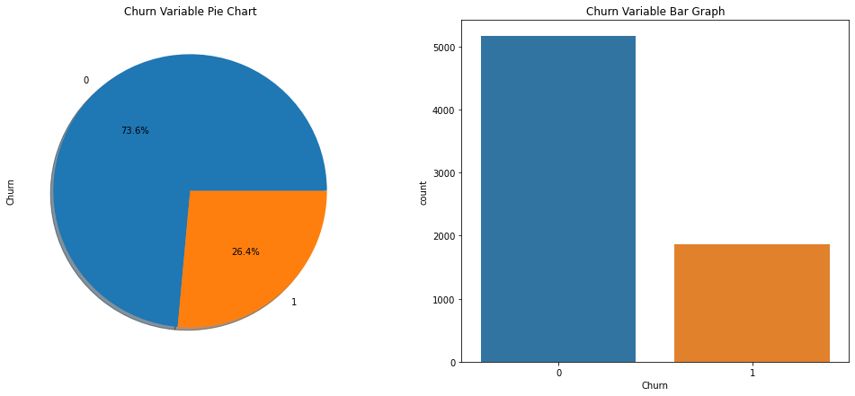

```python
f,axes=plt.subplots(1,2,figsize=(17,7))
df['Churn'].value_counts().plot.pie(autopct='%1.1f%%',ax=axes[0],shadow=True)
sns.countplot('Churn',data=df,ax=axes[1],order=[0,1])
axes[0].set_title('Churn Variable Pie Chart')
axes[1].set_title('Churn Variable Bar Graph')
plt.show()
```

We can see that the Target feature is highly imbalanced.we need to balance the dataset before building the model.

### Segregatiing predictors vs target features

```python
X=df.drop(columns="Churn")
y=df["Churn"]
```

Since there are no Ordinal categorical features we can go for One-Hot encoding

**One hot encoding**

```python
X=pd.get_dummies(X,drop_first=True)
```

**Scaling the continuous features**

```python
scaler = StandardScaler()
temp=X[num_cols] #Temporary dataframe
temp[num_cols]= scaler.fit_transform(temp)
```

Applying the scaled data to the dataframe X

```python
X[num_cols]=temp
```

Saving the cleaned dataset as CSV file for future use

```python
new_df=X.join(y,how='inner')
new_df.to_csv("clean_dataset")
```

### Train-Test split

```python
X_train, X_test, y_train, y_test = train_test_split(X, y, test_size=0.30, random_state=10,stratify = y)
```

## 6. Model training,testing and tuning

### Decision Tree

```python
dTree = DecisionTreeClassifier(criterion = 'gini', random_state=1)
dTree.fit(X_train, y_train)
```

```
DecisionTreeClassifier(random_state=1)
```

```python
print("Decision Tree Training data score: ",dTree.score(X_train, y_train))
print("Decision Tree Testing data score: ",dTree.score(X_test, y_test))
```

```
Decision Tree Training data score:  0.9973544973544973
Decision Tree Testing data score:  0.7133364973896535
```

Our model is Overfitting

*Reducing over fitting (Regularization)*

```python
dTreeR = DecisionTreeClassifier(criterion = 'entropy', max_depth = 3, random_state=1)
dTreeR.fit(X_train, y_train)
print("Decision Tree Training data score: ",dTreeR.score(X_train, y_train))
print("Decision Tree Testing data score: ",dTreeR.score(X_test, y_test))
```

```
Decision Tree Training data score:  0.7612942612942613
Decision Tree Testing data score:  0.7655434266729948
```

```python
dTreeR = DecisionTreeClassifier(criterion = 'gini', max_depth = 3, random_state=1)
dTreeR.fit(X_train, y_train)
print("Decision Tree Training data score: ",dTreeR.score(X_train, y_train))
print("Decision Tree Testing data score: ",dTreeR.score(X_test, y_test))
```

```
Decision Tree Training data score:  0.7918192918192918
Decision Tree Testing data score:  0.7883246321784527
```

*Insight from the above models*

criterion='gini' yields better score than criterion = 'entropy' .So let us choose the model with criterion = 'gini'

*Important features in tree building*

```python
pd.DataFrame(dTreeR.feature_importances_, columns = ["Imp"], index = X_train.columns)
```

|  | Imp |
| --- | --- |
| tenure | 0.562789 |
| MonthlyCharges | 0.000000 |
| TotalCharges | 0.032723 |
| SeniorCitizen_1 | 0.000000 |
| Partner_Yes | 0.000000 |
| Dependents_Yes | 0.000000 |
| MultipleLines_No phone service | 0.000000 |
| MultipleLines_Yes | 0.000000 |
| InternetService_Fiber optic | 0.390733 |
| InternetService_No | 0.000000 |
| OnlineSecurity_No internet service | 0.000000 |
| OnlineSecurity_Yes | 0.000000 |
| OnlineBackup_No internet service | 0.000000 |
| OnlineBackup_Yes | 0.000000 |
| DeviceProtection_No internet service | 0.000000 |
| DeviceProtection_Yes | 0.000000 |
| TechSupport_No internet service | 0.000000 |
| TechSupport_Yes | 0.000000 |
| StreamingTV_No internet service | 0.000000 |
| StreamingTV_Yes | 0.000000 |
| StreamingMovies_No internet service | 0.000000 |
| StreamingMovies_Yes | 0.000000 |
| Contract_One year | 0.000000 |
| Contract_Two year | 0.013756 |
| PaperlessBilling_Yes | 0.000000 |
| PaymentMethod_Credit card (automatic) | 0.000000 |
| PaymentMethod_Electronic check | 0.000000 |
| PaymentMethod_Mailed check | 0.000000 |

*Insights*

*Confusion Matrix for Decision Tree*

```
Decision Tree Testing data score:  0.7883246321784527
```

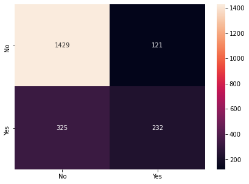

```python
print("Decision Tree Testing data score: ",dTreeR.score(X_test , y_test))
y_predict = dTreeR.predict(X_test)

cm = confusion_matrix(y_test, y_predict, labels=[0, 1])

df_cm = pd.DataFrame(cm, index = [i for i in ["No","Yes"]],
                  columns = [i for i in ["No","Yes"]])
plt.figure(figsize = (7,5))
sns.heatmap(df_cm, annot=True ,fmt='g')
plt.show()
```

*Classification report for Decision Tree Classifier*

```python
print("classification  Matrix:\n",classification_report(y_test,y_predict))
```

```
classification  Matrix:
               precision    recall  f1-score   support

           0       0.81      0.92      0.87      1550
           1       0.66      0.42      0.51       557

    accuracy                           0.79      2107
   macro avg       0.74      0.67      0.69      2107
weighted avg       0.77      0.79      0.77      2107
```

### Ensemble Learning - Bagging

```python
bgcl = BaggingClassifier(base_estimator=dTree, n_estimators=10,random_state=1)

bgcl = bgcl.fit(X_train, y_train)

print("Ensemble learning(Bagging) Training data score: ",bgcl.score(X_train,y_train))
print("Ensemble learning(Bagging) Testing data score: ",bgcl.score(X_test,y_test))
```

```
Ensemble learning(Bagging) Training data score:  0.9784289784289785
Ensemble learning(Bagging) Testing data score:  0.7755102040816326
```

Our model is overfitting, we need to do hyperparameter tuning

*Confusion Matrix for Bagging Classifier*

```
0.7755102040816326
```

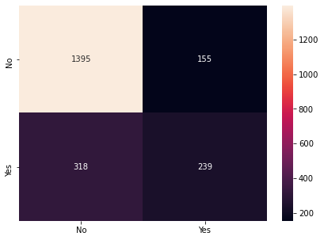

```python
y_predict = bgcl.predict(X_test)

print(bgcl.score(X_test , y_test))

cm=confusion_matrix(y_test, y_predict,labels=[0, 1])

df_cm = pd.DataFrame(cm, index = [i for i in ["No","Yes"]],
                  columns = [i for i in ["No","Yes"]])
plt.figure(figsize = (7,5))
sns.heatmap(df_cm, annot=True ,fmt='g')
```

*Classification report for Bagging Classifier*

```python
print("classification  Matrix:\n",classification_report(y_test,y_predict))
```

```
classification  Matrix:
               precision    recall  f1-score   support

           0       0.81      0.90      0.86      1550
           1       0.61      0.43      0.50       557

    accuracy                           0.78      2107
   macro avg       0.71      0.66      0.68      2107
weighted avg       0.76      0.78      0.76      2107
```

### Ensemble Learning - AdaBoosting

```python
abcl = AdaBoostClassifier(n_estimators=10, random_state=1)
abcl = abcl.fit(X_train, y_train)

print("Ensemble learning(AdaBoosting) Training data score: ",abcl.score(X_train,y_train))
print("Ensemble learning(AdaBoosting) Testing data score: ",abcl.score(X_test,y_test))
```

```
Ensemble learning(AdaBoosting) Training data score:  0.7985347985347986
Ensemble learning(AdaBoosting) Testing data score:  0.7906976744186046
```

*Confusion Matrix for AdaptiveBoosting Classifier*

```
0.7906976744186046
```

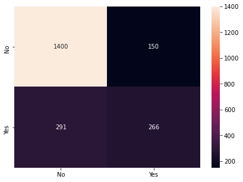

```python
y_predict = abcl.predict(X_test)
print(abcl.score(X_test , y_test))

cm=confusion_matrix(y_test, y_predict,labels=[0, 1])

df_cm = pd.DataFrame(cm, index = [i for i in ["No","Yes"]],
                  columns = [i for i in ["No","Yes"]])
plt.figure(figsize = (7,5))
sns.heatmap(df_cm, annot=True ,fmt='g')
```

*Classification report for AdaptiveBoosting Classifier*

```python
print("classification  Matrix:\n",classification_report(y_test,y_predict))
```

```
classification  Matrix:
               precision    recall  f1-score   support

           0       0.83      0.90      0.86      1550
           1       0.64      0.48      0.55       557

    accuracy                           0.79      2107
   macro avg       0.73      0.69      0.71      2107
weighted avg       0.78      0.79      0.78      2107
```

### Ensemble Learning - GradientBoost

```python
gbcl = GradientBoostingClassifier(n_estimators = 50,random_state=1)
gbcl = gbcl.fit(X_train, y_train)

print("Ensemble learning(GradientBoosting) Training data score: ",gbcl.score(X_train,y_train))
print("Ensemble learning(GradientBoosting) Testing data score: ",gbcl.score(X_test,y_test))
```

```
Ensemble learning(GradientBoosting) Training data score:  0.8158323158323159
Ensemble learning(GradientBoosting) Testing data score:  0.8025628856193641
```

*Confusion Matrix for GradientBoosting Classifier*

```
0.8025628856193641
```

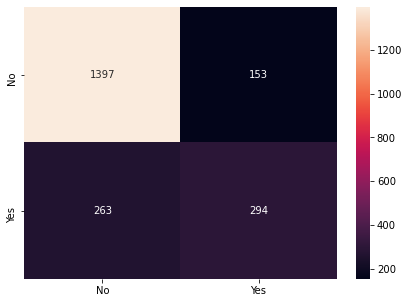

```python
y_predict = gbcl.predict(X_test)
print(gbcl.score(X_test, y_test))
cm=confusion_matrix(y_test, y_predict,labels=[0, 1])

df_cm = pd.DataFrame(cm, index = [i for i in ["No","Yes"]],
                  columns = [i for i in ["No","Yes"]])
plt.figure(figsize = (7,5))
sns.heatmap(df_cm, annot=True ,fmt='g')
```

*Classification report for GradientBoost Classifier*

```python
print("classification  Matrix:\n",classification_report(y_test,y_predict))
```

```
classification  Matrix:
               precision    recall  f1-score   support

           0       0.84      0.90      0.87      1550
           1       0.66      0.53      0.59       557

    accuracy                           0.80      2107
   macro avg       0.75      0.71      0.73      2107
weighted avg       0.79      0.80      0.80      2107
```

### Ensemble RandomForest Classifier

```python
rfcl = RandomForestClassifier(n_estimators = 50, random_state=1,max_features=12)
rfcl = rfcl.fit(X_train, y_train)

print("Ensemble learning(RandomForest) Training data score: ",rfcl.score(X_train,y_train))
print("Ensemble learning(RandomForest) Testing data score: ",rfcl.score(X_test,y_test))
```

```
Ensemble learning(RandomForest) Training data score:  0.9967439967439967
Ensemble learning(RandomForest) Testing data score:  0.7906976744186046
```

Our model is overfitting, we need to do hyperparameter tuning

*Confusion Matrix for RandomForest Classifier*

```
0.7906976744186046
```

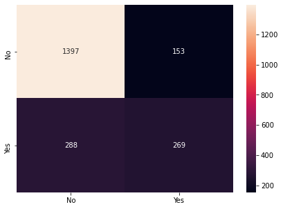

```python
y_predict = rfcl.predict(X_test)
print(rfcl.score(X_test, y_test))
cm=confusion_matrix(y_test, y_predict,labels=[0, 1])

df_cm = pd.DataFrame(cm, index = [i for i in ["No","Yes"]],
                  columns = [i for i in ["No","Yes"]])
plt.figure(figsize = (7,5))
sns.heatmap(df_cm, annot=True ,fmt='g')
```

*Classification report for Randomforest Classifier*

```python
print("classification  Matrix:\n",classification_report(y_test,y_predict))
```

```
classification  Matrix:
               precision    recall  f1-score   support

           0       0.83      0.90      0.86      1550
           1       0.64      0.48      0.55       557

    accuracy                           0.79      2107
   macro avg       0.73      0.69      0.71      2107
weighted avg       0.78      0.79      0.78      2107
```

### Final model

*We can see that from all the above models Gradient boosting is performing well, it has higher accuracy and f1 score, So we will choose GradientBoosting as our final model.*

## Conclusion

```
Dataset is imbalanced.Suggesting to collect data equally for all the classes.

We are choosing GradientBoosting Classifier as our final model,because it has higher accuracy and good f1 score

Numerical features are not Normally distributed

Gender,PhoneService features has no effect on target variable, So next time when we collect data it is not needed
to gather these two features

TotalCharges feature has some empty space values, in future avoid entering empty spaces into the CSV file
```